# Importing Libraries

```python
import pandas as pd
from sklearn.feature_extraction.text import CountVectorizer
from sklearn.decomposition import LatentDirichletAllocation
from sklearn.feature_extraction import text
import matplotlib.pyplot as plt
from wordcloud import WordCloud
import seaborn as sns
```

```python
hData = pd.read_csv("C:\\Users\\aloky\\OneDrive\\Desktop\\Sentiment Analysis\\god knows\\Processed\\waiting_area_processed.csv")
```

```python
hData.head()
```

|  | Unnamed: 0 | Tweets | Sentiment |
| --- | --- | --- | --- |
| 0 | 0 | indigo6e airline pain waiting 30 min baggage d... | Neutral |
| 1 | 1 | much bangalore airport t2 wonderful inside out... | Positive |
| 2 | 2 | 4060mins waiting uberola bangalore airport 12 ... | Positive |
| 3 | 3 | looks like waiting area first floor bangalore ... | Positive |
| 4 | 4 | matter fancy airport inaugurated problem remai... | Neutral |

```python
hData = hData.drop(hData.columns[hData.columns.str.contains('Unnamed', case=False)], axis=1)
```

```python
hData.head()
```

|  | Tweets | Sentiment |
| --- | --- | --- |
| 0 | indigo6e airline pain waiting 30 min baggage d... | Neutral |
| 1 | much bangalore airport t2 wonderful inside out... | Positive |
| 2 | 4060mins waiting uberola bangalore airport 12 ... | Positive |
| 3 | looks like waiting area first floor bangalore ... | Positive |
| 4 | matter fancy airport inaugurated problem remai... | Neutral |

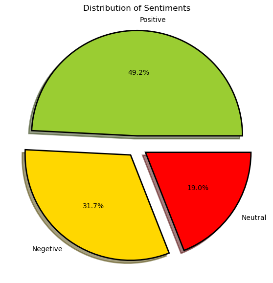

```python
# Pie-Chart
fig = plt.figure(figsize=(7,7))
colors = ("yellowgreen", "gold", "red")
wp={'linewidth':2, 'edgecolor':"black"}
tags = hData['Sentiment'].value_counts()
explode = (0.1, 0.1, 0.1)
tags.plot(kind='pie', shadow=True, colors=colors, autopct='%1.1f%%', wedgeprops=wp, explode=explode, label='')
plt.title("Distribution of Sentiments")
```

## Analysis on the Negetive Tweets

```python
# Collecting all the Negetive Tweets from the dataset
negetive_tweets = hData[hData.Sentiment == 'Negetive']

negetive_reviwes = negetive_tweets['Tweets'].tolist()
```

```python
custom_stop_words = ["experience", "nice", "facilities", "staff", "domestic", "terminal", "international",
                     "visit", "time", "comfortable","already", "amp", "guys", "pls", 'im', "us", "another",
                     "next", "god", "hope", "bless", "value", "dearest", "get" , "im", "mins", "till", "still", "already"]
```

```python
from nltk.corpus import stopwords
stop_words = set(stopwords.words('english'))
new_stop_words = [frozenset(stop_words)]
stop_words = new_stop_words + custom_stop_words
```

```python
# Weightage of the words in the tweets
vectorizer = CountVectorizer(max_df = 0.95, min_df = 2, stop_words = new_stop_words)
x = vectorizer.fit_transform(negetive_reviwes)
```

```python
# Lda model
num_topics = 10
lda = LatentDirichletAllocation(n_components = num_topics, random_state=40)
lda.fit(x)
```

```
LatentDirichletAllocation(random_state=40)
```

```python
num_top_words = 10
feature_names = vectorizer.get_feature_names_out()
topics=[]
```

```python
# Extracting the topics from LDA model
for topic_idx, topic in enumerate(lda.components_):
    top_words_idx = topic.argsort()[:-num_top_words - 1:-1]
    top_words = [feature_names[i] for i in top_words_idx]
    topics.append(top_words)

for i, topic in enumerate(topics):
    print(f"Topic {i+1}: {',' .join(topic)}")
```

```
Topic 1: hours,experience,pathetic,since,indigo6e,past,really,wrong,amp,area
Topic 2: waiting,area,hours,service,domestic,pathetic,flight,indigo6e,30,worst
Topic 3: flight,waiting,delayed,today,pune,travelling,customer,line,didnt,worst
Topic 4: indigo6e,get,staff,waiting,next,fight,20,mins,us,area
Topic 5: time,waiting,hour,domestic,serious,luggage,airline,30,guys,area
Topic 6: hours,pathetic,train,im,midnight,checkin,fight,delayed,waiting,flight
Topic 7: one,waiting,also,area,hours,service,domestic,pathetic,flight,indigo6e
Topic 8: akasaair,money,people,waiting,flight,one,taking,amp,us,mins
Topic 9: flight,back,mumbai,hours,help,get,delayed,waiting,sitting,area
Topic 10: flight,waiting,indigo6e,service,worst,till,still,sitting,time,already
```

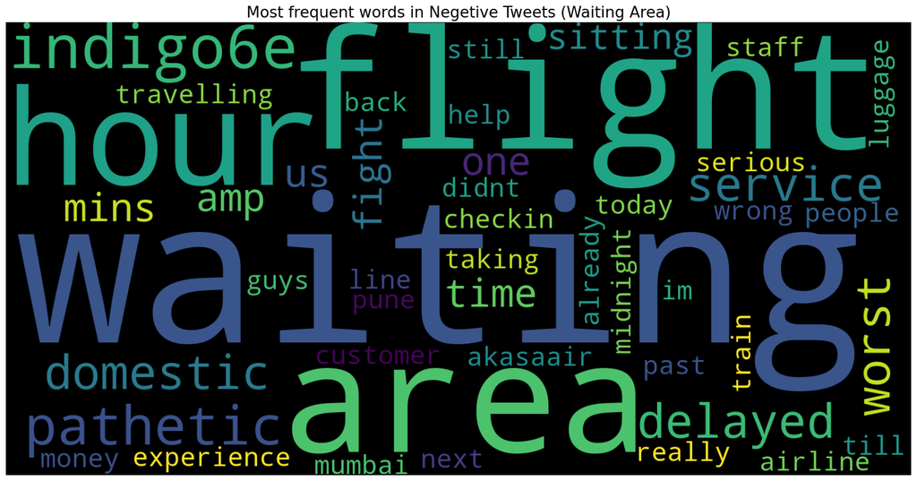

```python
# WordCloud
res = [' '.join(ele) for ele in topics]
text = ' '.join([word for word in res])
plt.figure(figsize=(20,15), facecolor='None')
wordcloud= WordCloud(max_words=500, width=1600, height=800).generate(text)
plt.imshow(wordcloud, interpolation='bilinear')
plt.axis("off")
plt.title('Most frequent words in Negetive Tweets (Waiting Area)', fontsize=19)
plt.show()
```

# Observation for negative tweets:

## 1) Flight Delays and Waiting Time:

#### • Passengers have complained about the prolonged waiting times lasting for hours, both on the ground and in the air.

#### • There were many complaints that talked about flights being delayed without proper announcements or updates.

## 2) Customer Service and Communication:

#### • Numerous concerns were expressed regarding poor customer service from various airlines which included staff not being very responsive to the passengers needs.

#### • There was a lack of communication from the airlines about flight delays or any changes that led to passenger dissatisfaction.

## 3) Inadequate assistance during emergencies and wheelchair services:

#### • Especially for senior citizens. They faced a lot of difficulties with wheelchair services which included prolonged waits and inadequate assistance.

#### • Inadequate assistance during medical emergencies were reported,which was about delays in providing necessary support and guidance.

#### • There were no medical stores available in the Airport .

## 4) Terminal Management and Infrastructure:

#### • Complaints were basically raised about the mismanagement at the terminal which included issues with the boarding, check-in counters and pickup points.

#### • Some passengers even criticised the airport's infrastructure and space management which are problems like overcrowding, inadequate facilities, and poor planning.

## 5) Missed Flights and Financial Losses:

#### • Passengers also reported many incidents of missed flights which resulted in financial losses. Some stated that they were not appropriately informed about the delays which led to their missed flights

## Analysis on the Positive Tweets

```python
import pandas as pd
from sklearn.feature_extraction.text import CountVectorizer
from sklearn.decomposition import LatentDirichletAllocation
from sklearn.feature_extraction import text
import matplotlib.pyplot as plt
from wordcloud import WordCloud
import seaborn as sns
custom_stop_words = ["experience", "nice", "facilities", "staff", "domestic", "terminal", "international",
                     "visit", "time", "comfortable", "much", "waiting", "time", "need", "also", "first", "since",
                     "always", "please", "last", "even", "near", "entire", "lot", "many", "used", "one", "entire", "though",
                     "amp", "us", "guys", "lol", "ps", "knows", "long", "inside", "many"]
stop_words = stop_words + custom_stop_words
new_stop_words = [frozenset(stop_words)]
```

```python
# Collecting all the Positive Tweets from the dataset
positive_tweets = hData[hData.Sentiment == 'Positive']
positive_reviews = positive_tweets['Tweets'].tolist()
```

```python
# Weightage of the words in the tweets
vectorizer = CountVectorizer(max_df = 0.95, min_df = 2, stop_words = stop_words)
x = vectorizer.fit_transform(positive_reviews)
```

```python
# Lda model
num_topics = 10
lda = LatentDirichletAllocation(n_components = num_topics, random_state=1)
lda.fit(x)
```

```
LatentDirichletAllocation(random_state=1)
```

```python
num_top_words = 10
feature_names = vectorizer.get_feature_names_out()
topics=[]
```

```python
# Extracting the topics from LDA model
for topic_idx, topic in enumerate(lda.components_):
    top_words_idx = topic.argsort()[:-num_top_words - 1:-1]
    top_words = [feature_names[i] for i in top_words_idx]
    topics.append(top_words)

for i, topic in enumerate(topics):
    print(f"Topic {i+1}: {',' .join(topic)}")
```

```
Topic 1: wifi,road,t2,big,bag,service,baggage,months,city,area
Topic 2: food,good,great,lounge,today,security,area,well,ground,service
Topic 3: area,floor,security,better,check,like,lounge,today,hospitality,flight
Topic 4: city,fuel,check,respected,offers,road,beyond,passengers,area,hospitality
Topic 5: passengers,white,great,beyond,flight,bag,ground,big,better,hundreds
Topic 6: flight,30,baggage,india,service,air,well,hospitality,good,area
Topic 7: area,seat,hundreds,hi,air,thanks,respected,dont,hospitality,today
Topic 8: good,dont,today,blrairport,like,took,india,hi,ground,hospitality
Topic 9: hospitality,best,offers,road,area,today,flight,months,service,blrairport
Topic 10: good,lounge,months,blrairport,really,thanks,flight,area,hospitality,today
```

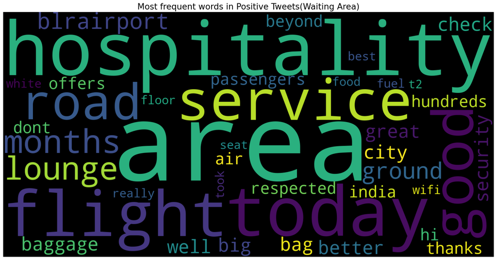

```python
# WordCloud
res = [' '.join(ele) for ele in topics]
text = ' '.join([word for word in res])
plt.figure(figsize=(20,15), facecolor='None')
wordcloud= WordCloud(max_words=500, width=1600, height=800).generate(text)
plt.imshow(wordcloud, interpolation='bilinear')
plt.axis("off")
plt.title('Most frequent words in Positive Tweets(Waiting Area)', fontsize=19)
plt.show()
```

# Observation for positive tweets:

## 1) Infrastructure Improvements:

#### • Since the waiting area on the first floor of Bangalore Airport's Terminal 1 has been revamped has led to the improved passenger experiences.

#### • specific staff members at the airport provided efficient and friendly assistance enhancing the overall travel experience for passengers.

## 2) Improved Security Measures:

#### • the improved security measures at Bangalore Airport which includes the opening of additional windows at the immigration area and faster processing times.

## 3) Convenient Amenities and Facilities:

#### • Many positive experiences were given for the availability of facilities such as lounges, Wi-Fi services and well-maintained waiting areas.

## 4) Convenient location and accessibility:

#### • The convenient location of the Red Key Airport Hotel on Kempegowda International Airport Road was mentioned which offered budget-friendly accommodation and welcoming hospitality for guests.

## 5) Efficient Service and Support:

#### • They also highlighted where the ground staff of different airlines including IndiGo, were praised for their proactive and affectionate approachs making the passengers feel quite welcomed and valued.